# Facebook Interaction Trends - FreeCodeCamp

Lacey Jeroue

11/6/2019

## Introduction

FreeCodeCamp provided data from posts on their facebook page. The dataset includes date and time the post was made, the type of post (whether it was a link, video, photo, or status), number of users reached, and user interactions (clicks or reactions). Matthew Barlowe provided the initial dive into cleaning and exploratory analysis. Here, I go a step further and examine the user reactions by facebook post topics.

How, if at all, are interactions towards Free Code Camp’s Facebook posts changing over the year? Is the content of Free Code Camp’s posts driving any of those changes?

Check out the dataset and documentation here: https://github.com/freeCodeCamp/open-data/tree/master/facebook-fCC-data

## Prepare the workspace

```r
# Load Packages
library(tidyverse)
library(RCurl)
library(lubridate)
library(pander)
library(tm)
library(wordcloud)

panderOptions('table.split.table', Inf)  # Do not split table

# Load the Facebook dataset from FreeCodeCamp on github
gitURL <- getURL("https://raw.githubusercontent.com/freeCodeCamp/open-data/master/facebook-fCC-data/data/freeCodeCamp-facebook-page-activity.csv")
fb <- read_csv(gitURL)


# Address (convert) variable class
fb <- fb %>%
  mutate_each(mdy, "date") %>%
  mutate_each(as.numeric, "reactions")


# Take a look at the dataset
str(fb)
```

```
## Classes 'spec_tbl_df', 'tbl_df', 'tbl' and 'data.frame': 420 obs. of  7 variables:
##  $ date     : Date, format: "2017-08-18" "2017-08-18" ...
##  $ time     : 'hms' num  15:45:00 11:27:00 19:18:00 16:55:00 ...
##   ..- attr(*, "units")= chr "secs"
##  $ title    : chr  "The origins of t-distributions and how they can help you make accurate estimates from small sample sizes." "How one camper got his developer dream job" "Trying to code when chat's open" "An interaction designer explains how a \"homeless iPhone\" might work." ...
##  $ type     : chr  "Link" "Link" "Video" "Link" ...
##  $ reach    : num  1768 6941 17399 3751 18248 ...
##  $ clicks   : num  44 536 2236 167 1946 ...
##  $ reactions: num  21 99 750 10 474 56 466 403 217 109 ...
```

## Add Variables

```r
# Add proportion of clicks per users reached & proporiton of reactions per user clicks
fb <- mutate(fb,
             propClicks = clicks / reach,
             propReactions = reactions / reach)


# Get sample size by post type
type_n <- fb %>%
  group_by(type) %>%
  summarize(
    Qty_PostType = n()
  )


# Add label including sample size for plotting later
fb <- left_join(fb, type_n)
fb <- fb %>%
  mutate(Type = paste0(type, "\nn = ", Qty_PostType))


# Add date & time variables
fb <- fb %>%
  mutate(week = week(date),
         year = year(date),
         month = month(date, label = T, abbr = T),
         datetime = make_datetime(year, month,
                                  day = day(date),
                                  hour = as.numeric(substr(time, 1, 2)),
                                  min = as.numeric(substr(time, 4, 5))))
```

## Remove data

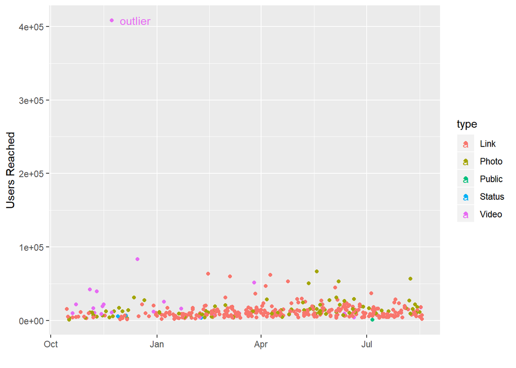

```r
fbdat <- fb %>%
  filter(reach < 100000 &
           !type %in% c("Public", "Status")
  )
```

## User Interactions

Users more often clicked a link when the post additionally had a photo or a video. Over the course of the year, 12% of users on average clicked a post containing a photo or video compared to 7% for posts containing only a link. Users were also more likely to react to a post when the post contained a photo or video.

| Type | Average Clicks | Average Reactions |
| --- | --- | --- |
| Link | 7.4% | 1.9% |
| Photo | 11.8% | 3.2% |
| Video | 11.8% | 2.4% |

[output not shown]

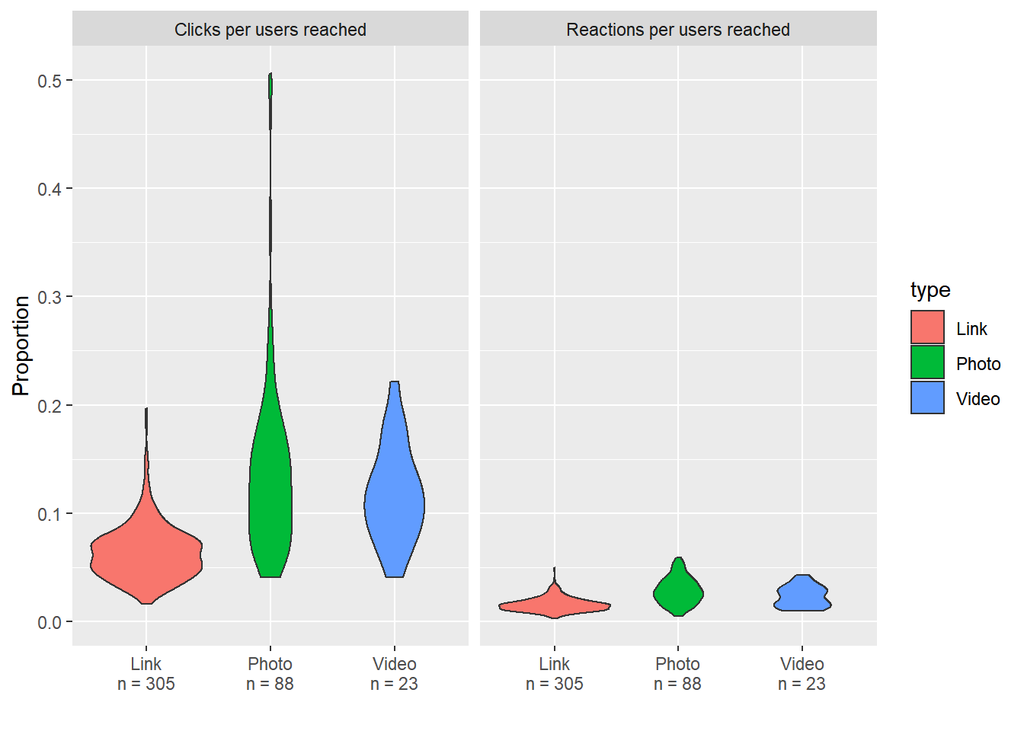

## Posts over time

Now we are going to look at total posts by week to reduce the noice in daily posts and get a better picture of the annual pattern. From the graphic below, it is clear that clicks increased over the study year.

```r
# Aggregate by week for a summarized dataset
fb_week <- fbdat %>%
  group_by(week, year) %>%
  summarize(n_posts = n(),
            sum_reach = sum(reach),
            sum_click = sum(clicks),
            mean_clicks = mean(clicks),
            mean_propClicks = mean(propClicks),
            mean_propReaction = mean(propReactions),
            mean_reachedPerPost = sum_reach / n_posts) %>%
  arrange(year, week)


# Standardize the week number to begin with one
# (this works becuase posts were made each week and none were missing)
fb_week$weekNo <- seq(1, nrow(fb_week))


# Get more meaningful x labels for graphing (month rather than week number)
labels <- unique(fbdat[,c("week","month")])
labels <- left_join(labels, fb_week[,c("week", "weekNo")])
labels <- labels[order(labels$weekNo), ]
label <- NULL
for(i in unique(labels$month)){         # some weeks span two months
  labelx <- labels[labels$month == i, ] # choose earliest week for each month
  labelx <- labelx[labelx$weekNo == min(labelx$weekNo), ]
  label <- rbind(label, labelx)
}
```

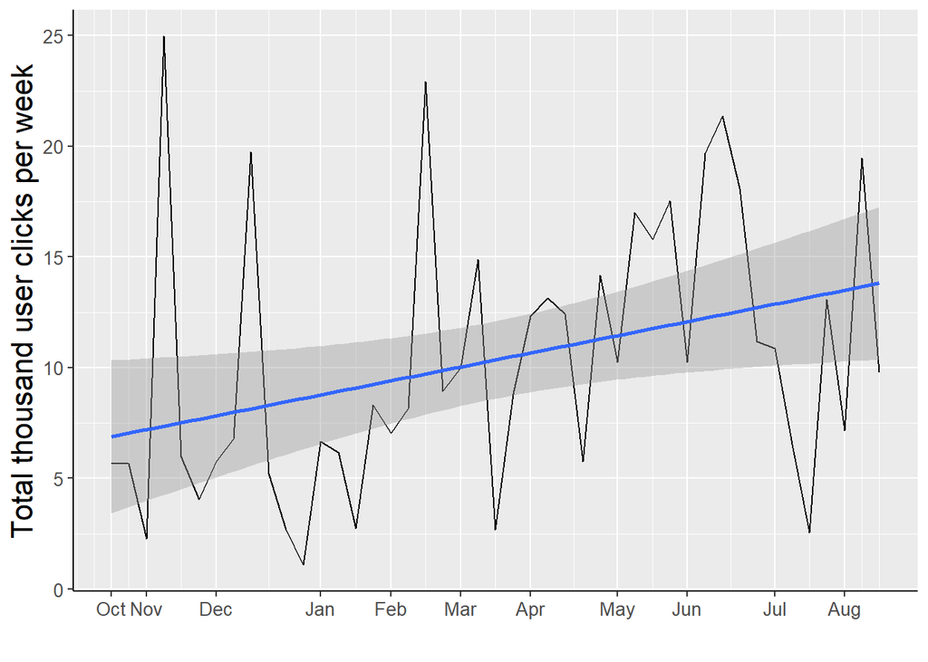

```r
# The plot
fb_week %>%
  mutate(clicked1000 = sum_click/1000) %>%
  ggplot(aes(weekNo, clicked1000)) +
  geom_line() +
  geom_smooth(method = "lm") +
  labs(y = "Total thousand user clicks per week", x = "") +
  scale_x_continuous(breaks = label$weekNo,
                     labels = label$month) +
  theme(axis.line = element_line(),
        text = element_text(size=rel(4)))
```

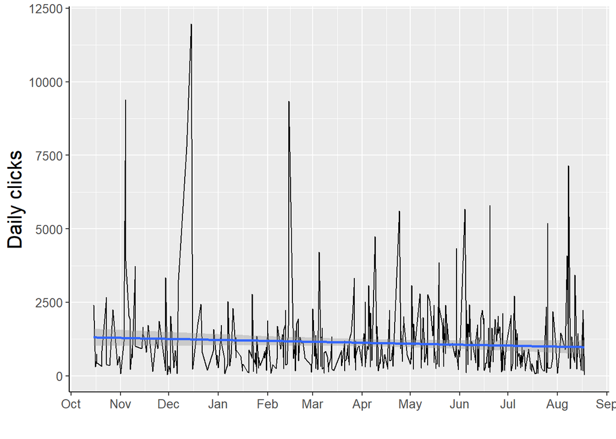

```r
fbdat %>%
ggplot(aes(date, clicks)) +
  geom_line() +
  geom_smooth(method = "lm") +
  labs(y = "Daily clicks", x = "") +
  scale_x_date(date_breaks = "1 month",
               date_labels = "%b") +
  theme(axis.line = element_line(),
        text = element_text(size=rel(4)))
```

### User click rates increased over the year!

### Well, not so fast!!

It is important to take into account the number of posts from which a user was inspired to click. When we look at the number of posts over time, it is clear that Free Code Camp has increased it’s social media presense on Facebook over the year. By just looking at the total clicks it is impossible to see if clicks are increasing because posts are increasing.

We need to look at the proportion of clicks per post to understand whether user interactions are increasing due to post content rather than the increased Facebook posts.

#### First, check out how facebook posts have increased

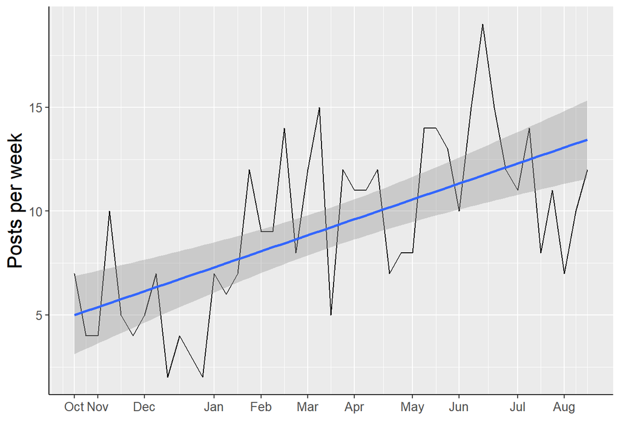

```r
ggplot(fb_week, aes(weekNo, n_posts)) +
  geom_line() +
  geom_smooth(method = "lm") +
  labs(y = "Posts per week", x = "") +
  scale_x_continuous(breaks = label$weekNo,
                   labels = label$month) +
  theme(axis.line = element_line(),
        text = element_text(size=rel(4)))
```

#### Now, see how the relative number of users reached hasn’t changed over the year

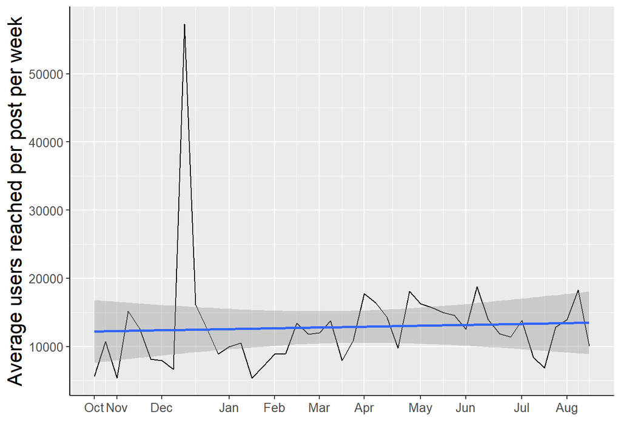

```r
fb_week %>%
  ggplot(aes(weekNo, mean_reachedPerPost)) +
  geom_line() +
  geom_smooth(method = "lm") +  # second in a week
  labs(y = "Average users reached per post per week", x = "") +
  scale_x_continuous(breaks = label$weekNo,
                     labels = label$month) +
  theme(axis.line = element_line(),
        text = element_text(size=rel(4)))
```

#### Last, check out how the click rate is actually falling!

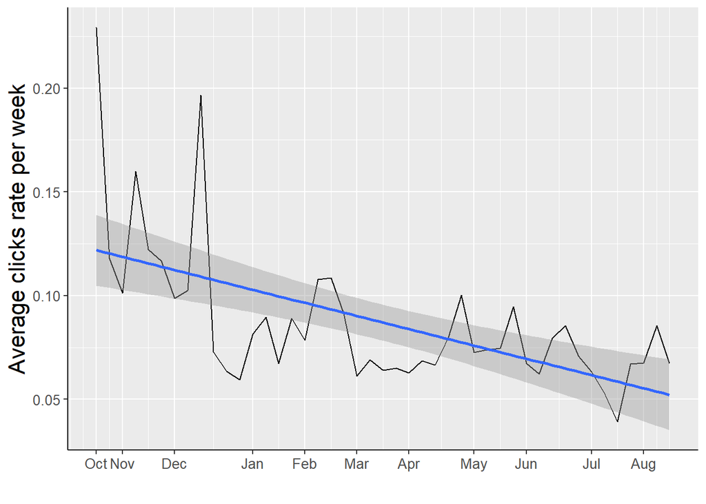

```r
fb_week %>%
  ggplot(aes(weekNo, mean_propClicks)) +
  geom_line() +
  geom_smooth(method = "lm") +
  labs(y = "Average clicks rate per week", x = "") +
  scale_x_continuous(breaks = label$weekNo,
                     labels = label$month) +
  theme(axis.line = element_line(),
        text = element_text(size=rel(4)))
```

### Take a look at post type

```r
# Aggregate by week for a summarized dataset
fb_week_type <- fbdat %>%
  group_by(type, week, year) %>%
  summarize(n_posts = n(),
            sum_reach = sum(reach),
            mean_propClicks = mean(propClicks),
            mean_propReaction = mean(propReactions),
            mean_reachedPerPost = sum_reach / n_posts) %>%
  arrange(year, week)


# Standardize the week number to begin with one
fb_week_type <- left_join(fb_week_type, fb_week[,c("week", "weekNo")])
```

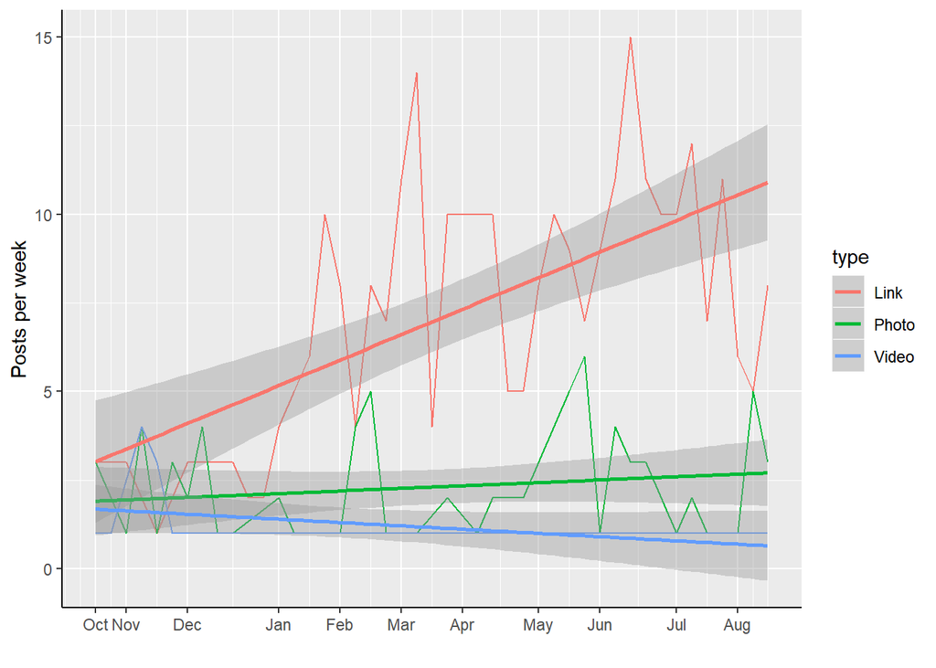

```r
ggplot(fb_week_type) +
  geom_line(aes(weekNo, n_posts, col = type)) +
  geom_smooth(method = "lm", aes(weekNo, n_posts, col = type)) +
  labs(y = "Posts per week", x = "") +
  scale_x_continuous(breaks = label$weekNo,
                     labels = label$month) +
  theme(axis.line = element_line())
```

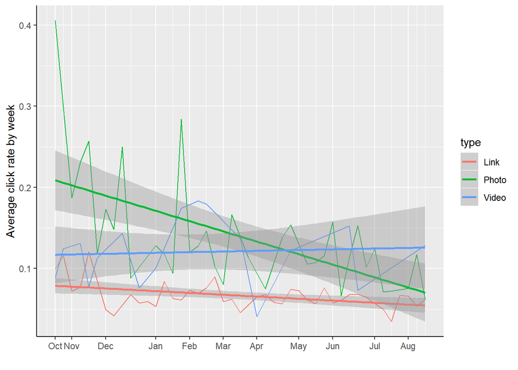

```r
ggplot(fb_week_type) +
  geom_line(aes(weekNo, mean_propClicks, col = type)) +
  geom_smooth(method = "lm", aes(weekNo, mean_propClicks, col = type)) +
  labs(y = "Average click rate by week", x = "") +
  scale_x_continuous(breaks = label$weekNo,
                     labels = label$month) +
  theme(axis.line = element_line())
```

## Post Topics & “buzzwords”

### Top 5 Titles

Let’s take a look at the top 5 most clicked posts for links and photos

```r
clickable_Titles <- rbind(fbdat %>%
                     filter(type == "Link") %>%
                     select(type, title, propClicks) %>%
                     arrange(desc(propClicks)) %>%
                     top_n(5),
                   fbdat %>%
                     filter(type == "Photo") %>%
                     select(type, title, propClicks) %>%
                     arrange(desc(propClicks)) %>%
                     top_n(5)
)

names(clickable_Titles) <- c("Type", "Post Title", "Click Rate")
```

| Type | Post Title | Click Rate |
| --- | --- | --- |
| Link | Freecodecamp shared your post. | 0.1966 |
| Link | Before you drop $2000 on a MacBook read this. | 0.1831 |
| Link | Freecodecamp shared your post. | 0.1559 |
| Link | Stay safe out there. | 0.1468 |
| Link | You can’t make this stuff up. | 0.1447 |
| Photo | Only 5 hours left! Get your low-effort Halloween costume: https://teespring.com/low-effort-coder-halloween#pid=2&cid=2397&sid=front | 0.506 |
| Photo | Only one day left to get this low effort Halloween costume: freecodecamp.com/shop | 0.4817 |
| Photo | Timeline Photos | 0.3661 |
| Photo | This subway map shows how agile software development methods relate to one another. | 0.2841 |
| Photo | We either need to significantly improve security or keep some of these devices offline. | 0.257 |

### Buzzwords

Now let’s pull out common words from the post titles and look at post click rates for posts containing those common words.

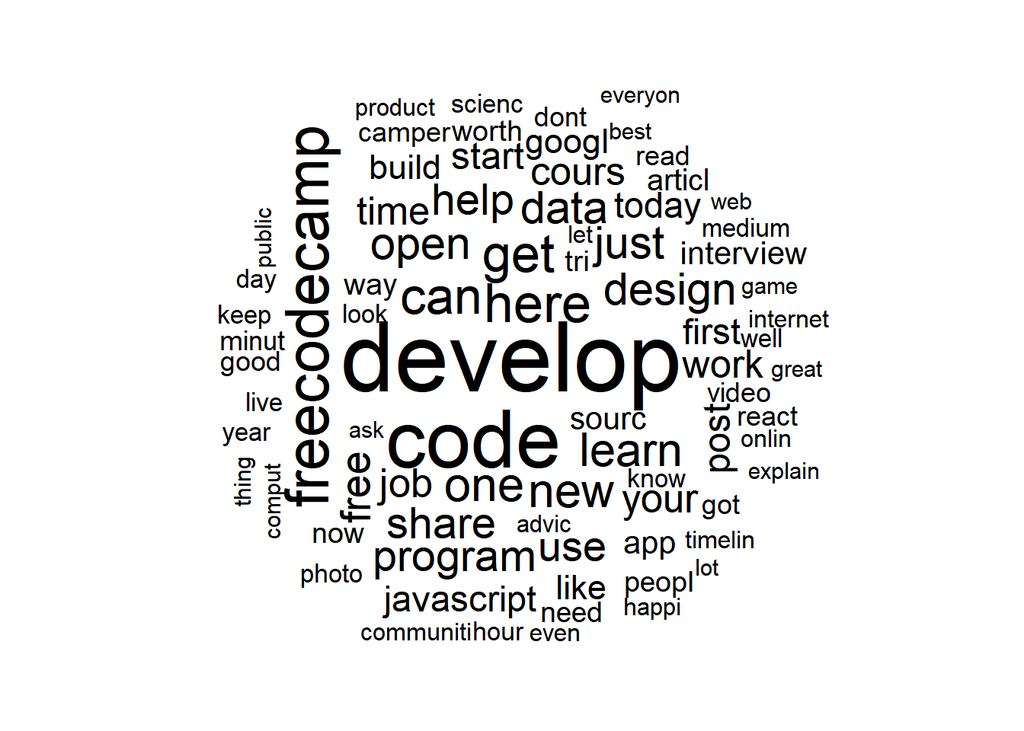

```r
# Create a 'corpus' object via the  text mining, tm package
post_titles <- str_to_lower(fbdat$title) #pulls the titles into a chr vector
post_corpus <- post_titles %>%
  VectorSource() %>%
  Corpus() %>%
  tm_map(removePunctuation) %>%
  tm_map(removeWords, stopwords('english')) %>%
  tm_map(removeNumbers) %>%
  tm_map(stemDocument) %>%
  tm_map(stripWhitespace)


# Make a word cloud
wordcloud::wordcloud(post_corpus, max.words = 80, random.order = FALSE)
```

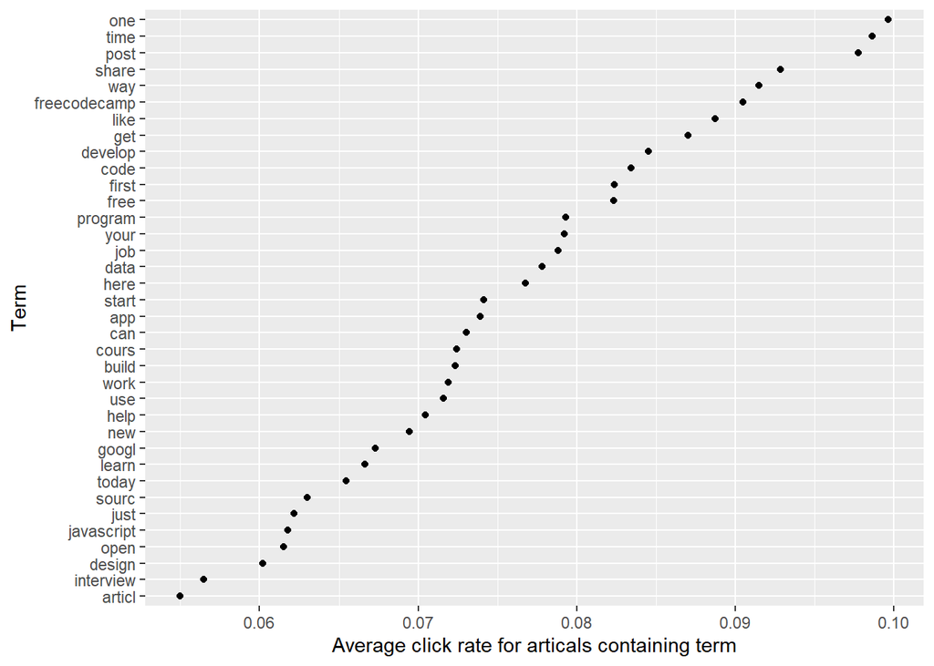

```r
# Isolate common words into a Text documet matrix
commonWords_tdm <- post_corpus %>%
  TermDocumentMatrix() %>%
  removeSparseTerms(0.99)

# Convert TDM to tibble
commonWords <- commonWords_tdm %>% as.matrix()
commonWords <- tibble(Terms = rownames(commonWords),
                      freq = rowSums(commonWords)) %>%
  arrange(desc(freq))


# Get the average proportion of clicks for articals containing each buzzword
wordClicks <- NULL
for(word in findFreqTerms(commonWords_tdm, 12)){ # only terms that occur 12+ times
  modeldf <- fbdat %>%
    filter(str_detect(str_to_lower(title), word))
  wordclicksx <- tibble(Buzzword = word,
                        avg.prop.clicks = mean(modeldf$propClicks),
                        sd = sd(modeldf$propClicks),
                        n = nrow(modeldf))
  wordClicks <- rbind(wordClicks, wordclicksx)
}


# Visualize clicks by buzzword
ggplot(wordClicks, aes(x = reorder(Buzzword, avg.prop.clicks), y =avg.prop.clicks)) +
  geom_point() +
  coord_flip() +
  labs(y = "Average click rate for articals containing term", x = "Term")
```